# IODS course project

Next we form baseline for analysis at starting point of measurements and compare differencies with variance analysis.

```
## Analysis of Variance Table
##
## Response: mean
##           Df Sum Sq Mean Sq   F value   Pr(>F)
## baseline   1 253625  253625 1859.8201 1.57e-14 ***
## Group      2    879     439    3.2219  0.07586 .
## Residuals 12   1636     136
## ---
## Signif. codes:  0 '***' 0.001 '**' 0.01 '*' 0.05 '.' 0.1 ' ' 1
```

we found baseline to be most significant explainer for means

Nest we plot BPRS data to explore how treatment effect over weeks

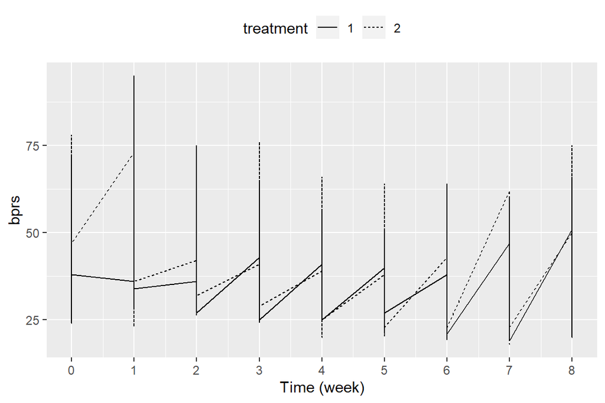

There seems to be trend similarly over weeks in bprs regarding treatment

Linear model can be used to estimate dependencies among variables.

```
##
## Call:
## lm(formula = bprs ~ week + treatment, data = BPRSL)
##
## Residuals:
##     Min      1Q  Median      3Q     Max
## -22.454  -8.965  -3.196   7.002  50.244
##
## Coefficients:
##             Estimate Std. Error t value Pr(>|t|)
## (Intercept)  46.4539     1.3670  33.982   <2e-16 ***
## week         -2.2704     0.2524  -8.995   <2e-16 ***
## treatment2    0.5722     1.3034   0.439    0.661
## ---
## Signif. codes:  0 '***' 0.001 '**' 0.01 '*' 0.05 '.' 0.1 ' ' 1
##
## Residual standard error: 12.37 on 357 degrees of freedom
## Multiple R-squared:  0.1851, Adjusted R-squared:  0.1806
## F-statistic: 40.55 on 2 and 357 DF,  p-value: < 2.2e-16
```

We can see that week and treatment can explain 18 percent of bprs. and week is of them most significant.

We should also make random intercept model giving variance differentiate between sucjects.

```
## Linear mixed model fit by maximum likelihood  ['lmerMod']
## Formula: bprs ~ week + treatment + (1 | subject)
##    Data: BPRSL
##
##      AIC      BIC   logLik deviance df.resid
##   2748.7   2768.1  -1369.4   2738.7      355
##
## Scaled residuals:
##     Min      1Q  Median      3Q     Max
## -3.0481 -0.6749 -0.1361  0.4813  3.4855
##
## Random effects:
##  Groups   Name        Variance Std.Dev.
##  subject  (Intercept)  47.41    6.885
##  Residual             104.21   10.208
## Number of obs: 360, groups:  subject, 20
##
## Fixed effects:
##             Estimate Std. Error t value
## (Intercept)  46.4539     1.9090  24.334
## week         -2.2704     0.2084 -10.896
## treatment2    0.5722     1.0761   0.532
##
## Correlation of Fixed Effects:
##            (Intr) week
## week       -0.437
## treatment2 -0.282  0.000
```

We should also build reference model, wher we add random slope model by week and subject.

```
## Linear mixed model fit by maximum likelihood  ['lmerMod']
## Formula: bprs ~ week + treatment + (week | subject)
##    Data: BPRSL
##
##      AIC      BIC   logLik deviance df.resid
##   2745.4   2772.6  -1365.7   2731.4      353
##
## Scaled residuals:
##     Min      1Q  Median      3Q     Max
## -2.8919 -0.6194 -0.0691  0.5531  3.7977
##
## Random effects:
##  Groups   Name        Variance Std.Dev. Corr
##  subject  (Intercept) 64.8222  8.0512
##           week         0.9609  0.9803   -0.51
##  Residual             97.4304  9.8707
## Number of obs: 360, groups:  subject, 20
##
## Fixed effects:
##             Estimate Std. Error t value
## (Intercept)  46.4539     2.1052  22.066
## week         -2.2704     0.2977  -7.626
## treatment2    0.5722     1.0405   0.550
##
## Correlation of Fixed Effects:
##            (Intr) week
## week       -0.582
## treatment2 -0.247  0.000
```

```
## Data: BPRSL
## Models:
## BPRTS_ref: bprs ~ week + treatment + (1 | subject)
## BPRTS_ref1: bprs ~ week + treatment + (week | subject)
##            Df    AIC    BIC  logLik deviance  Chisq Chi Df Pr(>Chisq)
## BPRTS_ref   5 2748.7 2768.1 -1369.4   2738.7
## BPRTS_ref1  7 2745.4 2772.6 -1365.7   2731.4 7.2721      2    0.02636 *
## ---
## Signif. codes:  0 '***' 0.001 '**' 0.01 '*' 0.05 '.' 0.1 ' ' 1
```

We found this model be slightly significant different from random intercept model.

```
## boundary (singular) fit: see ?isSingular
```

```
## Linear mixed model fit by maximum likelihood  ['lmerMod']
## Formula: bprs ~ week + treatment + (week | treatment)
##    Data: BPRSL
##
##      AIC      BIC   logLik deviance df.resid
##   2843.3   2870.5  -1414.7   2829.3      353
##
## Scaled residuals:
##     Min      1Q  Median      3Q     Max
## -1.8254 -0.7276 -0.2585  0.5698  4.0819
##
## Random effects:
##  Groups    Name        Variance  Std.Dev. Corr
##  treatment (Intercept) 3.147e-02  0.17739
##            week        1.964e-03  0.04432 -1.00
##  Residual              1.516e+02 12.31297
## Number of obs: 360, groups:  treatment, 2
##
## Fixed effects:
##             Estimate Std. Error t value
## (Intercept)  46.4539     1.3670  33.982
## week         -2.2704     0.2533  -8.964
## treatment2    0.5722     1.2979   0.441
##
## Correlation of Fixed Effects:
##            (Intr) week
## week       -0.741
## treatment2 -0.475  0.000
## convergence code: 0
## boundary (singular) fit: see ?isSingular
```

```
## Data: BPRSL
## Models:
## BPRTS_ref2: bprs ~ week + treatment + (week | treatment)
## BPRTS_ref1: bprs ~ week + treatment + (week | subject)
##            Df    AIC    BIC  logLik deviance  Chisq Chi Df Pr(>Chisq)
## BPRTS_ref2  7 2843.3 2870.5 -1414.7   2829.3
## BPRTS_ref1  7 2745.4 2772.6 -1365.7   2731.4 97.896      0  < 2.2e-16 ***
## ---
## Signif. codes:  0 '***' 0.001 '**' 0.01 '*' 0.05 '.' 0.1 ' ' 1
```

We will plot next bprs over time as before.

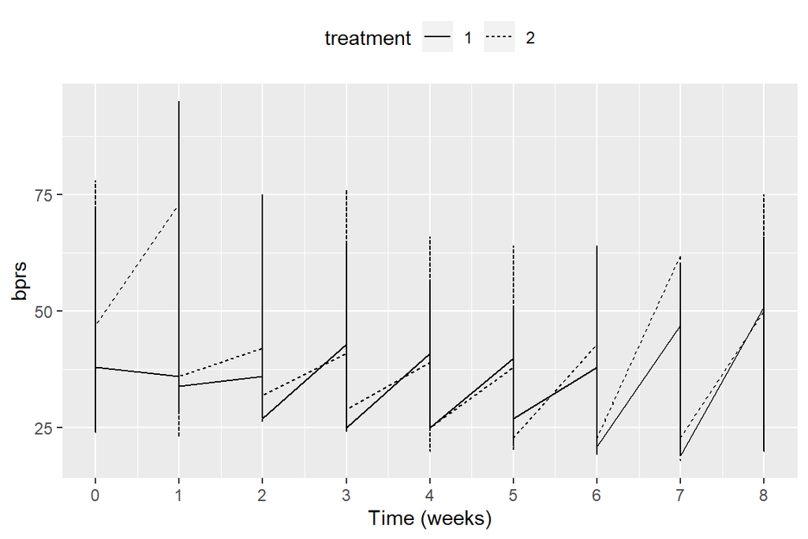

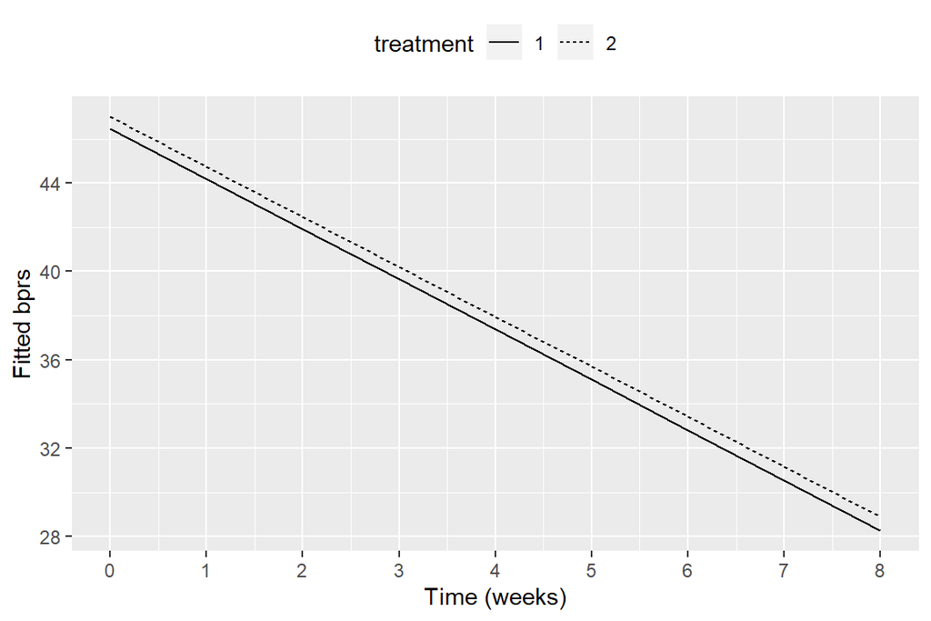